# Data Expedition: Using R to investigate the epidemiology of parasites in geladas

This lab introduces the basics of data visualization in R. In the exercises at the end, you will develop your own hypotheses and visually explore patterns of infection and mortality in a dataset on gelada monkeys and tapeworms.

You should have already gone to the [R website](https://cran.r-project.org/) and installed the appropriate version of R for your operating system. (if you missed class on Monday, please do this step now!)

## Introducing R and data visualization

In this section, we will generate artificial data and produce some basic visualizations in R. You will later apply these techniques with real data in the exercises. Simple modifications to this code will be sufficient to complete the exercises at the end.

To begin, open R on your computer. You will see a window that you can type into much like a calculator: this is the R command line. Try typing and `2 + 2` onto the command line and hit `enter`:

```r
2 + 2
```

```
## [1] 4
```

Throughout this document, you can copy and paste the blocks of R code highlighted with `gray boxes` into your own R console to mimic what I’m doing. The white boxes that begin with a ‘##’ are the output from R that you should see in your R console if you enter the code in the gray box (e.g., entering ‘2 + 2’ into R produces the answer ‘4’, as seen above in the white box). Keep in mind that some blocks of code only work if you have already entered earlier blocks of code. Lines beginning with a hashtag are ‘comments’ to help us keep track of what the code is doing, and are ignored by R.

R has many built in functions for manipulating data and for performing mathematical and statistical operations. For example, we can create a vector of numbers ‘x’ and then use the `sum` function to add them up:

```r
# create vector of numbers using 'c()'
x = c(1, 2, 3)

# add them up
sum(x)
```

```
## [1] 6
```

Now, let’s use some special R functions to generate fake data that we will use to demonstrate some of R’s visualization functions. Copy and paste the following block of code into R and hit `enter`. Don’t worry about how this code works- you won’t need to do anything like this for the exercise:

```r
# generate random data with 20 rows
set.seed(0)
fakedata = data.frame(
  color = sample(c("blue", "green"), 20, replace=T),
  direction = sample(c("up", "down"), 20, replace=T),
  size = rnorm(20),
  speed = rnorm(20))
```

Now, let’s look at the object `fakedata` we just created by entering its name on the R command line:

```r
fakedata
```

```
##    color direction        size       speed
## 1  green      down -0.22426789  1.75790309
## 2   blue      down  0.37739565  0.56074609
## 3   blue        up  0.13333636 -0.45278397
## 4  green      down  0.80418951 -0.83204330
## 5  green        up -0.05710677 -1.16657055
## 6   blue        up  0.50360797 -1.06559058
## 7  green        up  1.08576936 -1.56378205
## 8  green        up -0.69095384  1.15653700
## 9  green        up -1.28459935  0.83204713
## 10 green      down  0.04672617 -0.22732869
## 11  blue        up -0.23570656  0.26613736
## 12  blue        up -0.54288826 -0.37670272
## 13  blue      down -0.43331032  2.44136463
## 14 green        up -0.64947165 -0.79533912
## 15  blue        up  0.72675075 -0.05487747
## 16 green      down  1.15191175  0.25014132
## 17  blue      down  0.99216037  0.61824329
## 18 green      down -0.42951311 -0.17262350
## 19 green        up  1.23830410 -2.22390027
## 20  blue      down -0.27934628 -1.26361438
```

We have two *categorical variables* (color and direction), and two *continuous variables* (size and speed). There are several types of plots we can make with this data. First, use the `attach` function to ‘attach’ the data in your R session- this is just a convenient trick that allows us to refer to individual columns of the data by simply typing the column name (some warning messages may pop up on your R console, but it’s nothing to worry about!):

```r
# attach data
attach(fakedata)

# test it out by typing the name of one of the columns in fakedata
color
```

```
##  [1] green blue  blue  green green blue  green green green green blue
## [12] blue  blue  green blue  green blue  green green blue
## Levels: blue green
```

We can visualize the distribution of *a single numerical variable* with a **histogram**. This is useful for answering questions like “are values skewed? what is the average? how variable are the values?” For example, we can look at the histogram for “size” in our fake data, and see that it is centered around zero, it doesn’t seem to be skewed, and it ranges from about -1.5 to 1.5:

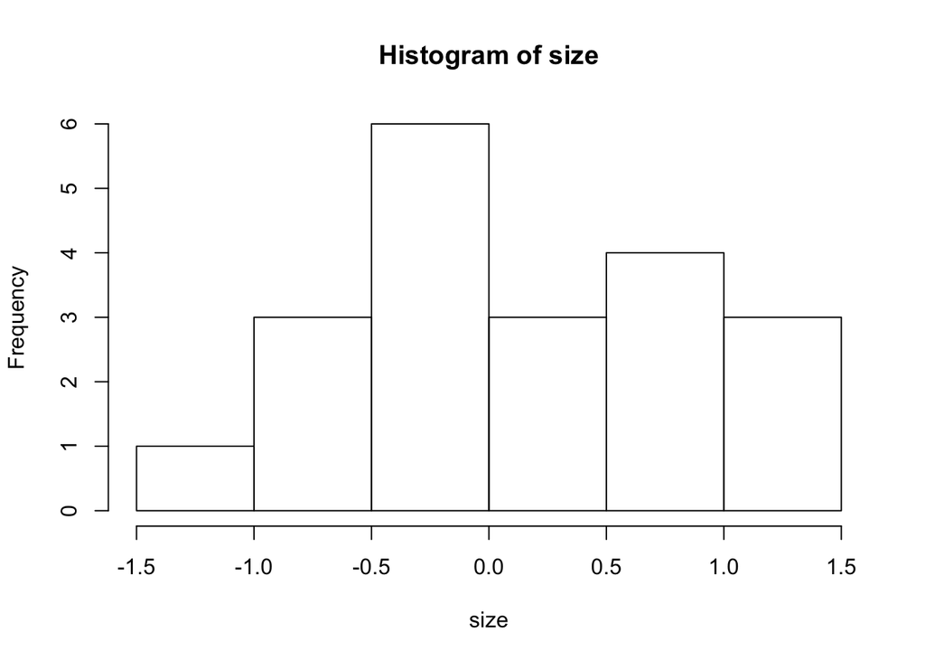

```r
# histogram of 'size'
hist(size)
```

We can visualize the distributions of *one numerical variable across different levels of a categorical variable* with a **boxplot**. This is useful if we want to compare the distribution of a variable across two or more categories, for example if we want to see whether the distribution of size is different for “blue” verses “green”:

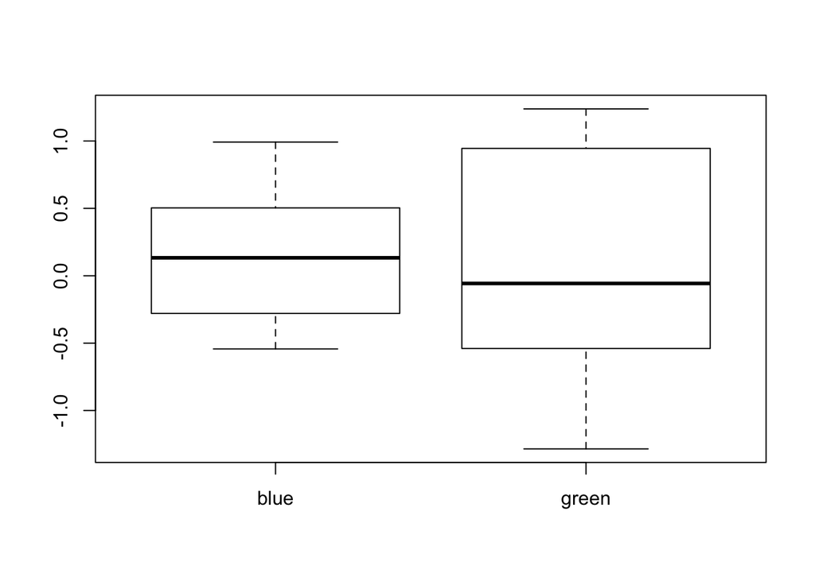

```r
# boxplot of 'size' verses 'color'
boxplot(size ~ color)
```

We can visualize the *relationship between a pair of numerical variables* with a **scatterplot**. Oftentimes, we expect variables to have a positive or negative association. Let’s look at the relationship between “size” and “speed” in our data:

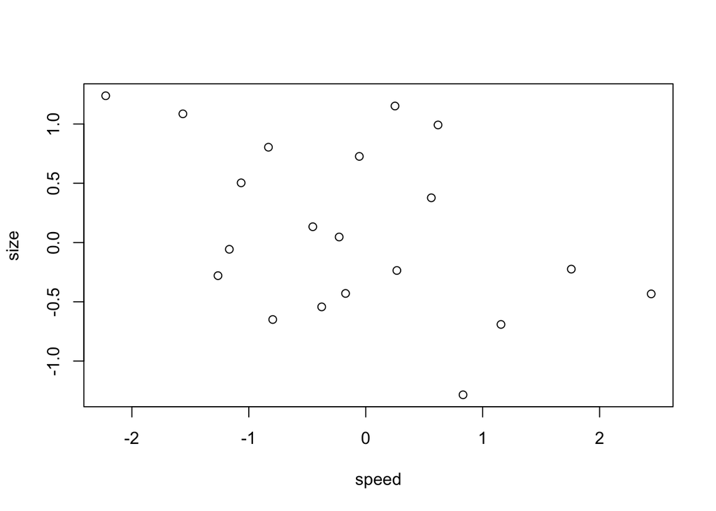

```r
# scatterplot of 'size' verses 'speed'
plot(size ~ speed)
```

```r
# make a table of color vs direction
tab = table(color, direction)
tab
```

```
##        direction
## color   down up
##   blue     4  5
##   green    5  6
```

Now we can feed this table to the `barplot` function. The setting `beside=TRUE` tells R to put the bars side-by-side rather than stacked, which is the default. The code below also illustrates how to specify additional graphical parameters, separated by commas, within the plot function to specify aesthetic features, such as colors for the bars (`col=c("blue", "green"`) and labels to put below the bars (`names.arg=c("down", "up")`):

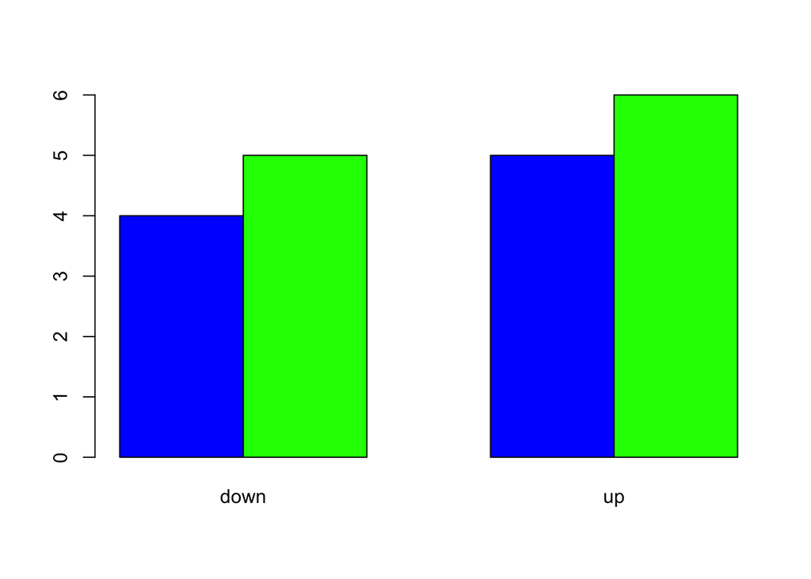

```r
# make barplot showing distribution of colors for up vs. down
barplot(tab, beside=TRUE, col=c("blue", "green"), names.arg=c("down", "up"))
```

You can see that the barplot corresponds to the values in the table: the lowest value, 4, is for ‘down, blue’, and the highest value, 6, is for ‘up, green’.